# lab14

Felix Pham

5/12/2019

```r
knitr::opts_chunk$set(echo = TRUE)
library(RCurl) # pull the text into R, using this package.
library(tidyverse)
library(magrittr) # to use extract() and extract2() functions.

macbeth_url <- "http://www.gutenberg.org/cache/epub/1129/pg1129.txt"
macbeth_raw <- getURL(macbeth_url) # got the HTML into R

## macbeth_raw

macbeth_line <- macbeth_raw %>%
  strsplit("\r\n")

## macbeth_line

## doesn’t quite work as expected when the data structure we start with is a list instead of a vector.

macbeth_lines <- macbeth_raw %>%
  strsplit("\r\n") %>% # break it up into lines, splitting on linebreaks
  extract2(1) # equivalent to [[1]] return single element instead of [1] sub-list by using extract() extract2 mean 2 "[]".

# Technically, nothing has changed except for the fact that instead of it being a list of 1 "thing", now we extract the thing and make it stand on its own!

## macbeth_lines

# \r Carriage
# return \n newline
```

Exercise 1: Use Regular Expressions to find all occurrences of either MACBETH or LADY MACBETH preceded by two spaces and followed by a period, at the start of a line.

```r
# Use Regular Expressions to find all occurrences of either MACBETH or LADY MACBETH preceded by two spaces and followed by a period, at the start of a line.


# MACBETH\\. = follow by a period
# ? = Matches at most 1 time; optional string
# ^ = Start of the string
# * = Matches at least 0 times
# grep(pattern, string, value = TRUE) --> Detect pattern, return string


set.seed(42)
grep("^  ([A-Z][A-Z]* )?MACBETH\\.", macbeth_lines, value = TRUE) %>%
  sample(10) # random sample, since head() only shows MACBETH lines
```

```
##  [1] "  LADY MACBETH. Alack, I am afraid they have awaked"
##  [2] "  LADY MACBETH. These deeds must not be thought"
##  [3] "  MACBETH. How say'st thou, that Macduff denies his person"
##  [4] "  MACBETH. To know my deed, 'twere best not know myself."
##  [5] "  MACBETH. What man dare, I dare."
##  [6] "  MACBETH. See, they encounter thee with their hearts' thanks."
##  [7] "  MACBETH. I will not yield,"
##  [8] "  MACBETH. Sweet remembrancer!"
##  [9] "  LADY MACBETH. That which hath made them drunk hath made me"
## [10] "  MACBETH. We will speak further."
```

```r
## Here's one that is more specific:
grep("^  (LADY )*MACBETH", macbeth_lines, value = TRUE) %>%
  sample(10)
```

```
##  [1] "  LADY MACBETH. Who was it that thus cried? Why, worthy Thane,"
##  [2] "  MACBETH. I wish your horses swift and sure of foot,"
##  [3] "  MACBETH. O, yet I do repent me of my fury,"
##  [4] "  MACBETH. Had I three ears, I'd hear thee."
##  [5] "  LADY MACBETH. Say to the King I would attend his leisure"
##  [6] "  LADY MACBETH. Thou'rt mad to say it!"
##  [7] "  LADY MACBETH. Almost at odds with morning, which is which."
##  [8] "  MACBETH. So shall I, love, and so, I pray, be you."
##  [9] "  LADY MACBETH. Nought's had, all's spent,"
## [10] "  MACBETH. Here had we now our country's honor roof'd,"
```

Exercise 2: Get the line numbers and lines for all spoken lines (i.e., starting with two spaces, any character name in all caps, followed by a period)

```r
# grep(pattern, string) --> Detect pattern, return the location of the string

line_numbers <-
  grep("^  [A-Z][A-Z ]+\\.", macbeth_lines) # return the line numbers.

line_text <- macbeth_lines %>% extract(line_numbers) # sub-list of line text based on line numbers

data.frame(line_numbers, line_text) %>% head() # create a new dataframe with those two variables.
```

```
##   line_numbers                                       line_text
## 1          148                                          ASCII.
## 2          290    FIRST WITCH. When shall we three meet again?
## 3          292       SECOND WITCH. When the hurlyburly's done,
## 4          294   THIRD WITCH. That will be ere the set of sun.
## 5          295                   FIRST WITCH. Where the place?
## 6          296                   SECOND WITCH. Upon the heath.
```

Exercise 3: Using the line text you extracted above, use str_extract() from the stringr library to pull out just the character name from each line. The syntax is str_extract(SOURCE_TEXT, QUOTED_REGEX_PATTERN) (or you can use the pipe syntax).

```r
## Note again the space in the brackets.  This is needed to match character
## names that contain spaces (such as LADY MACBETH)
characters <- line_text %>% str_extract("^  [A-Z][A-Z ]+\\.")
characters %>% sample(10)
```

```
##  [1] "  BANQUO."           "  MESSENGER."        "  FIRST MURTHERER."
##  [4] "  SIWARD."           "  MALCOLM."          "  ALL."
##  [7] "  SECOND MURTHERER." "  MURTHERER."        "  MALCOLM."
## [10] "  THIRD MURTHERER."
```

Aside (using gsub())

```r
spoken_text <-
  mapply(
    FUN      = gsub,
    pattern  = characters,  ## vary the pattern= argument over elements of `characters`
    x        = line_text,   ## vary the x= argument over elements of `line_text`
    MoreArgs = list(replacement = "") ## hold the replacement= argument fixed
    )
spoken_text %>% sample(10)
```

```
##                                           DUNCAN.
##     " No more that Thane of Cawdor shall deceive"
##                                     LADY MACBETH.
## " Who was it that thus cried? Why, worthy Thane,"
##                                  FIRST MURTHERER.
##                              " Wast not the way?"
##                                      FIRST WITCH.
##               " Ay, sir, all this is so. But why"
##                                        MURTHERER.
##    " Ay, my good lord. Safe in a ditch he bides,"
##                                 SECOND MURTHERER.
##                              " A light, a light!"
##                                     LADY MACBETH.
##                                     " Donalbain."
##                                           SIWARD.
##                        " Enter, sir, the castle."
##                                     LADY MACBETH.
##                      " A kind good night to all!"
##                                          MACBETH.
##                    " You are, and do not know't."
```

```r
frame <-
  data.frame(
    line = line_numbers,
    character = characters,
    line_text = spoken_text)
head(frame)
```

```
##   line       character                         line_text
## 1  148          ASCII.
## 2  290    FIRST WITCH.   When shall we three meet again?
## 3  292   SECOND WITCH.       When the hurlyburly's done,
## 4  294    THIRD WITCH.  That will be ere the set of sun.
## 5  295    FIRST WITCH.                  Where the place?
## 6  296   SECOND WITCH.                   Upon the heath.
```

## Cleaning the data: Pulling out just character names

```r
## Put parens around the part of the pattern you care about
## Refer to "whatever is matched" with \\1 in the replacement string
## Each parenthetical expression gets an index, \\1, \\2, etc.
frame <- frame %>%
  mutate(
    character = gsub("^  ([A-Z ]+)\\.", "\\1", character))
head(frame)
```

```
##   line    character                         line_text
## 1  148        ASCII
## 2  290  FIRST WITCH   When shall we three meet again?
## 3  292 SECOND WITCH       When the hurlyburly's done,
## 4  294  THIRD WITCH  That will be ere the set of sun.
## 5  295  FIRST WITCH                  Where the place?
## 6  296 SECOND WITCH                   Upon the heath.
```

## Computing some summary statistics

Exercise 4: Use your data wrangling skills to compute the key summary statistics for each character: first line, median line, last line, total number of lines, and percentage of total lines. Sort the results in decreasing order of number of lines. There’s no text manipulation needed here, but it’s a necessary step for our graphs.

```r
library(mosaic) # alters the functionality of sample()
character_stats <- frame %>%
  group_by(character) %>%
  summarize(
    num_lines = n(),
    pct_lines = 100 * n() / nrow(frame),
    first_appearance = min(line),
    halfway_point = round(median(line)),
    last_appearance = max(line)) %>%
  arrange(desc(num_lines))
character_stats %>% sample(10)
```

```
## # A tibble: 10 x 7
##    character num_lines pct_lines first_appearance halfway_point
##    <chr>         <int>     <dbl>            <int>         <dbl>
##  1 ROSS             39     6.06               369          2240
##  2 YOUNG SI…         3     0.466             3030          3032
##  3 BOTH MUR…         2     0.311             1557          1571
##  4 SEYTON            5     0.776             2842          2847
##  5 SERVANT           5     0.776             1600          2819
##  6 MURTHERER         4     0.621             1736          1741
##  7 BANQUO           33     5.12               444           942
##  8 SECOND A…         2     0.311             2127          2128
##  9 LADY MAC…        59     9.16               668          1253
## 10 MACDUFF          58     9.01              1159          2436
## # … with 2 more variables: last_appearance <int>, orig.id <chr>
```

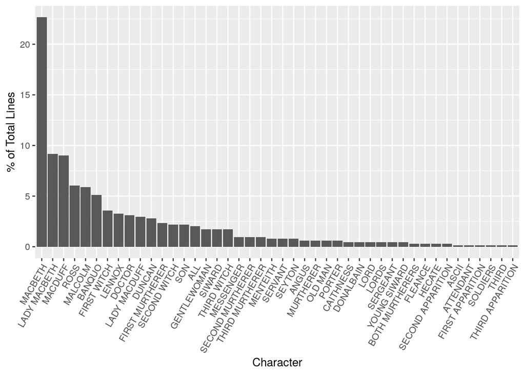

```r
character_stats <- character_stats %>%
  mutate(
    character = factor(character, levels = character))

character_stats %>%
  ggplot(aes(x = character, y = pct_lines)) +
  geom_bar(stat = "identity") +
  scale_x_discrete(name = "Character") +
  scale_y_continuous(name = "% of Total Lines") +
  theme(
    axis.text.x = element_text(angle = 60, hjust = 1))
```

## Computing some summary statistics

Exercise 5: Use filter() and summarize() to count up the lines and find the first and last appearance, by any character with less than 1% of total lines. (For the median just input NA) Bind this new summary data to the original data, having excluded the individual low-activity characters

```r
### Combine infrequent speakers into an "OTHERS" bin
low_freq_chars <- character_stats %>%
  filter(pct_lines < 1) %>%
  summarize(
    character = "OTHERS",
    num_lines = sum(num_lines),
    pct_lines = sum(pct_lines),
    first_appearance = min(first_appearance),
    halfway_point = NA,
    last_appearance = max(last_appearance))

### Replacing the lower activity characters with "OTHERS"
character_stats <-
  character_stats %>%
  filter(pct_lines >= 1) %>%
  rbind(low_freq_chars)
```

Exercise 6:

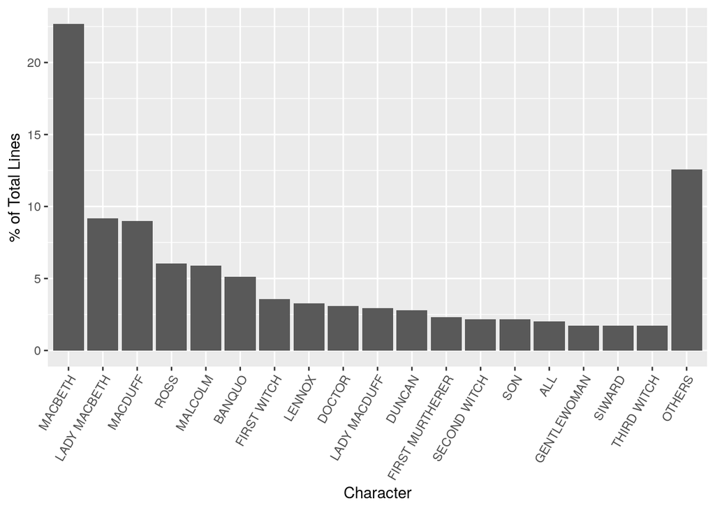

```r
### Bar plot v. 2
character_stats %>%
  ggplot(aes(x = character, y = pct_lines)) +
  geom_bar(stat = "identity") +
  scale_x_discrete(name = "Character") +
  scale_y_continuous(name = "% of Total Lines") +
  theme(
    axis.text.x = element_text(angle = 60, hjust = 1))
```

Exercise 7: See if you can produce the following graph, showing, for each character that has at least 1% of total lines, when they first speak, when they have spoken half their lines, and when they last speak.

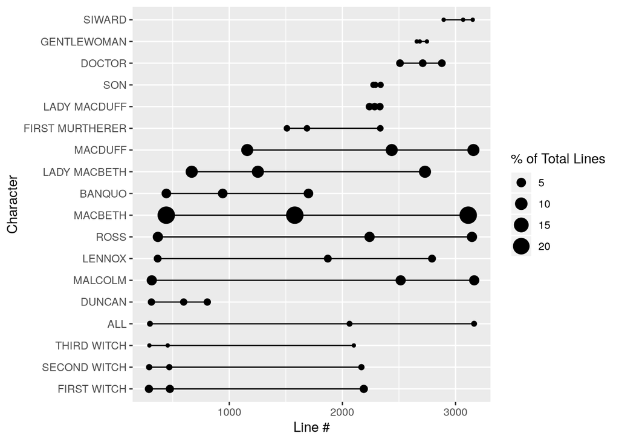

```r
### Graphing each character's first, middle and last lines
character_stats %>%
  filter(character != "OTHERS") %>%
  rename(
    first  = first_appearance,
    middle = halfway_point,
    last   = last_appearance) %>%
  mutate(
    character = reorder(character, first, min)) %>%
  gather(
    key   = label,
    value = line,
    first, middle, last) %>%
  ggplot(
    aes(
      x     = character,
      y     = line)) +
  geom_point(aes(size  = pct_lines)) +
  geom_line() +
  coord_flip() +
  scale_y_continuous(name = "Line #") +
  scale_x_discrete(name = "Character") +
  guides(size = guide_legend(title = "% of Total Lines"))
```

[figure not shown]

```r
library(RCurl)
library(tidyverse)
library(magrittr)
library(rvest)
RMJ <- "https://www.gutenberg.org/cache/epub/1112/pg1112.txt"
RMJRaw <- getURL(RMJ)
RMJPara <- RMJRaw %>%
  strsplit("\r\n") %>%
  extract2(1)
library(wordcloud)
library(tm) # text-mining package
RMJCorpus <- RMJPara %>%
  VectorSource() %>% # change the data type
  VCorpus() %>% # change the data type
  tm_map(stripWhitespace) %>% # remove spaces/line-breaks, etc.
  tm_map(removeNumbers) %>% # remove line numbers, etc.
  tm_map(removePunctuation) %>% # remove Punctuation.
  tm_map(content_transformer(tolower)) %>% # all lowercase.
  tm_map(removeWords, stopwords("english")) # remove function words
RMJCorpus %>% wordcloud(max.words = 50, scale = c(4, 1),colors=brewer.pal(8, "Set1"), random.color = FALSE)
```